# LDL PRS analysis

Similar to our analyses in UKB, we'd like to associate PRS with LDL in each ethnicity separately, normalize such that a unit of scaled PRS equates to a 40 mg/dL change, and then associate with CAD.

```r
library(viridis)    # A nice color scheme for plots.
library(ggthemes)   # Common themes to change the look and feel of plots.
library(scales)     # Graphical scales map data to aesthetics in plots.
library(skimr)      # Better summaries of data.
library(lubridate)  # Date library from the tidyverse.
library(tidyverse)  # Data wrangling packages.
library(bigrquery)  # Data extraction from Google BigQuery
library(data.table)
library(dplyr)
require(dplyr)
require(broom)
require(tidyr)
require(ggplot2)
require(data.table)
require(ggridges)


# Get the bucket name
my_bucket <- Sys.getenv('WORKSPACE_BUCKET')
```

```r
## load phenotype files

pheno_cad=fread("pheno_files//CAD_pheno.aou.v7.tsv")
pheno_ldl=fread("pheno_files/LDL_pheno.aou.v7.tsv")

# load covariate files

covs=fread("pheno_files/covariate_basics_230912.txt")
ethnicity=fread("pheno_files//ancestry_preds.tsv")

## prs

ldl_prs_afr=fread("summed_scores/LDL-AFR-GLGC.ALL.sscore")
ldl_prs_eur=fread("summed_scores/LDL-EUR-GLGC.ALL.sscore")
ldl_prs_sas=fread("summed_scores/LDL-SAS-GLGC.ALL.sscore")
```

Now we want to calculate ancestry specific thresholds for PRS. Let's get the PRS for African, European, and Asian ancestry that causes a 40 mmHg increase in LDL cholesterol. First, let's summarzie by ethnicity

```r
summary(as.factor(ethnicity$ancestry_pred))
```

**afr**

56913

**amr**

45035

**eas**

5706

**eur**

133581

**mid**

942

**sas**

3217

Now we grab the appropriate ethnicities and plot the PRS distribution:

```r
prs_AFR=merge(ldl_prs_afr[,c("IID","SCORE1_SUM")],
              ethnicity[ethnicity$ancestry_pred=="afr",c("research_id","ancestry_pred")],
              by.x="IID",by.y="research_id")
print(nrow(prs_AFR))
```

```
[1] 56913
```

```r
prs_EUR=merge(ldl_prs_eur[,c("IID","SCORE1_SUM")],
              ethnicity[ethnicity$ancestry_pred=="eur",c("research_id","ancestry_pred")],
              by.x="IID",by.y="research_id")
print(nrow(prs_EUR))
```

```
[1] 133581
```

```r
prs_SAS=merge(ldl_prs_sas[,c("IID","SCORE1_SUM")],
              ethnicity[ethnicity$ancestry_pred=="sas",c("research_id","ancestry_pred")],
              by.x="IID",by.y="research_id")
print(nrow(prs_SAS))
```

```
[1] 3217
```

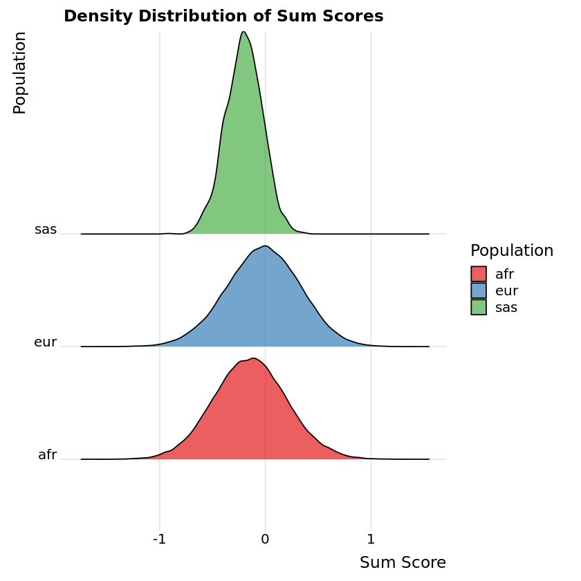

```r
## let's look at scores before normalization
combined_data <- rbind(prs_AFR, prs_EUR, prs_SAS)

colnames(combined_data)=c("ID","PRS","Population")
combined_data$Population=as.factor(combined_data$Population)
ggplot(combined_data, aes(x = PRS, y = Population, fill = Population)) +
   geom_density_ridges(alpha = 0.7) +
    scale_fill_brewer(palette = "Set1") +
    theme_ridges() + # Optional: Adds a nice theme suitable for ridgeline plots
     labs(title = "Density Distribution of Sum Scores",
     x = "Sum Score",
     y = "Population")
```

```r
## here we merged with covariates so we can model on PC
totaldata=merge(combined_data,covs,by.x="ID",by.y="person_id")
```

```r
dim(totaldata)
```

1. 193711

2. 24

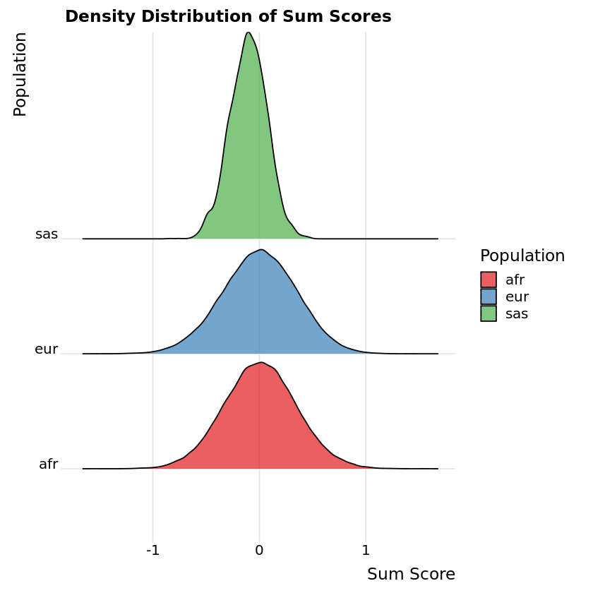

```r
pcmod=lm(PRS~PC1+PC2+PC3+PC4+PC5,data = totaldata)
totaldata$predictscore=predict(object = pcmod,newdata=totaldata)
totaldata$residscore=(totaldata$PRS-totaldata$predictscore)
totaldata$Population=as.factor(totaldata$Population)

## here are all the residualised scores
ggplot(totaldata, aes(x = residscore, y = Population, fill = Population)) +
    geom_density_ridges(alpha = 0.7) +
    scale_fill_brewer(palette = "Set1") +
    theme_ridges() + # Optional: Adds a nice theme suitable for ridgeline plots
    labs(title = "Density Distribution of Sum Scores",
         x = "Sum Score",
         y = "Population")
```

However, we notice that we want these scores to be on the N(0,1) scale:

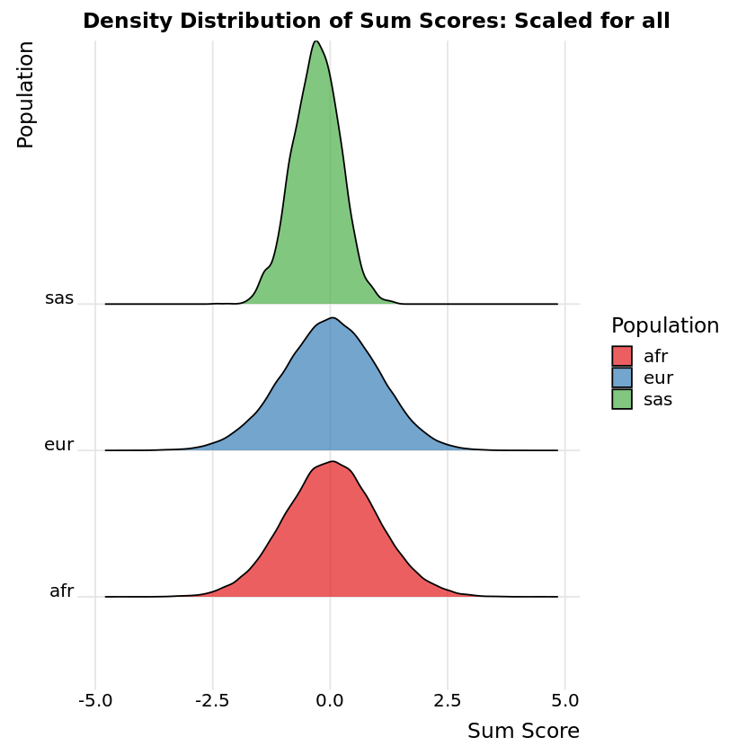

```r
## here are all the residualised scores scaled over ALL populaions

totaldata$scaled_residscore=scale(totaldata$residscore)
ggplot(totaldata, aes(x = scaled_residscore, y = Population, fill = Population)) +
    geom_density_ridges(alpha = 0.7) +
    scale_fill_brewer(palette = "Set1") +
    theme_ridges() + # Optional: Adds a nice theme suitable for ridgeline plots
    labs(title = "Density Distribution of Sum Scores: Scaled for all",
         x = "Sum Score",
         y = "Population")
```

We might also be interested in scaling each population separately, because we see that SAS tends to be enriched in low scoring PRS:

```
    Min.  1st Qu.   Median     Mean  3rd Qu.     Max.
-4.55043 -0.66682  0.00866  0.00000  0.67650  4.61021
```

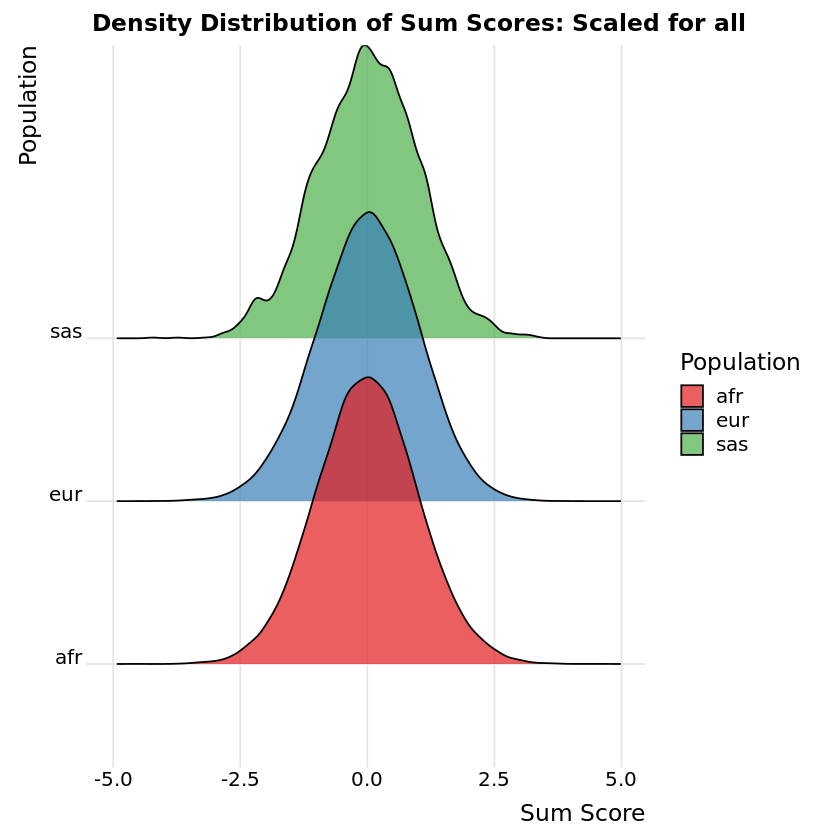

```r
totaldata$scaled_prs=rep(0,nrow(totaldata))
totaldata$scaled_prs[totaldata$Population%in%"afr"]=scale(totaldata$residscore[totaldata$Population%in%"afr"])
totaldata$scaled_prs[totaldata$Population%in%"eur"]=scale(totaldata$residscore[totaldata$Population%in%"eur"])
totaldata$scaled_prs[totaldata$Population%in%"sas"]=scale(totaldata$residscore[totaldata$Population%in%"sas"])

summary(totaldata$scaled_prs)
ggplot(totaldata, aes(x = scaled_prs, y = Population, fill = Population)) +
    geom_density_ridges(alpha = 0.7) +
    scale_fill_brewer(palette = "Set1") +
    theme_ridges() + # Optional: Adds a nice theme suitable for ridgeline plots
    labs(title = "Density Distribution of Sum Scores: Scaled for all",
         x = "Sum Score",
         y = "Population")
```

## Impact of PRS

To assess the impact of LDL-C PRS on CAD risk, you need to establish a two-step relationship: first, between LDL-C PRS and LDL-C levels (per 40 mg/dL change), and then between LDL-C PRS and CAD outcomes. This approach allows you to understand how changes in LDL-C levels attributed to genetic risk (as quantified by PRS) relate to CAD risk. Here's how you can approach this analysis for both European (EUR) and African (AFR) populations:

### Step 1: Associate LDL-C PRS with LDL-C Levels (per 40 mg/dL)

1. Linear Regression for LDL-C Levels: Fit a linear regression model with LDL-C levels as the outcome and LDL-C PRS as the predictor. You might want to adjust for relevant covariates.
2. Rescale the Coefficient for LDL-C PRS: Adjust the coefficient from this model to reflect a 40 mg/dL change in LDL-C.

### Step 2: Associate Rescaled LDL-C PRS with CAD

1. Incorporate Rescaled LDL-C PRS into Cox Model: Use the rescaled LDL-C PRS from Step 1 as a predictor in a Cox proportional hazards model to analyze its relationship with CAD risk.
2. Perform Analysis for Both EUR and AFR Populations: Repeat these steps separately for EUR and AFR populations to capture population-specific effects.

```r
library(dplyr)
library(survival)

#Merge with ldl, note this is a smaller subset we will use to assess the coefficient for scaling puproses
ldldat=merge(totaldata,pheno_ldl[,c("person_id","max_measurement")],by.x="ID",by.y="person_id")
ldldat=ldldat[!is.na(ldldat$max_measurement),]
caddat=merge(totaldata,pheno_cad,by.x="ID",by.y="person_id")
caddat=caddat[!is.na(caddat$total_pheno),]
dim(ldldat)
dim(caddat)
names(ldldat)
```

1. 84885

2. 29

1. 193706

2. 37

1. 'ID'

2. 'PRS'

3. 'Population'

4. 'sex_report'

5. 'sex_at_birth'

6. 'age'

7. 'anc_report'

8. 'anc_pred'

9. 'PC1'

10. 'PC2'

11. 'PC3'

12. 'PC4'

13. 'PC5'

14. 'PC6'

15. 'PC7'

16. 'PC8'

17. 'PC9'

18. 'PC10'

19. 'PC11'

20. 'PC12'

21. 'PC13'

22. 'PC14'

23. 'PC15'

24. 'PC16'

25. 'predictscore'

26. 'residscore'

27. 'scaled_residscore'

28. 'scaled_prs'

29. 'max_measurement'

Let's get some summary information on LDL by ancestry here to reassure ourselves that these measurements are reasonable:

```r
ldldat%>%group_by(Population)%>%summarise(mean(max_measurement),median(max_measurement),IQR(max_measurement),length(max_measurement))
caddat%>%group_by(Population)%>%summarise(mean(total_pheno),length(total_pheno))
```

A tibble: 3 × 5

| Population <fct> | mean(max_measurement) <dbl> | median(max_measurement) <dbl> | IQR(max_measurement) <dbl> | length(max_measurement) <int> |
| --- | --- | --- | --- | --- |
| afr | 123.8713 | 121 | 56 | 19540 |
| eur | 127.4612 | 126 | 53 | 64109 |
| sas | 124.4640 | 122 | 50 | 1236 |

A tibble: 3 × 3

| Population <fct> | mean(total_pheno) <dbl> | length(total_pheno) <int> |
| --- | --- | --- |
| afr | 0.06538279 | 56911 |
| eur | 0.07555885 | 133578 |
| sas | 0.03699099 | 3217 |

We show that this indeed translates to a Scaled LDL effect of 40 mg/Dl

### Let's try for AFR, SAS and EUR: We first show using the overall residual (unscaled):

```r
#List of unique populations
populations <- c("afr","sas","eur")

#Initialize an empty list for storing models and results
cox_models <- list()
glm_models=list()
for(pop in populations)
{
    print(pop)

#Subset data for the specific population
  pop_data_ldl<-ldldat[ldldat$Population%in%pop,]
  pop_data_cad<-caddat[caddat$Population%in%pop,]
 #print(nrow(pop_data_ldl))
    #print(nrow(pop_data_cad))

    # There are three choices for PRS, we can use the overall (unscaled) residual,
    #the scaled (overall residuals), or the population scaled residual

    #Choose residual score or PRS, here we use the populations scaled prs

    ## population scaled
    #pop_data_ldl$PRS=pop_data_ldl$scaled_prs
    ## unscaled residual score

    pop_data_ldl$PRS=pop_data_ldl$residscore

    ## scaled residual score (not population)
    #pop_data_ldl$PRS=pop_data_ldl$scaled_residscore

     print(paste0("population summary prs for population",pop))
    print(summary(pop_data_ldl$PRS))

    pop_data_ldl$sex=as.factor(ifelse(pop_data_ldl$sex_report=="Male",1,0))

    #print(paste0("Sex_summary for pop",pop))

    #print(summary(as.factor(pop_data_ldl$sex)))


      # Step 1: Linear Regression for LDL-C Levels
ldl_model <- lm(max_measurement ~ PRS + as.numeric(age) + as.factor(sex)+
                PC1+PC2+PC3+PC4+PC5+PC6+PC7+PC8+PC9+PC10,
                   data = pop_data_ldl)
  #summary(ldl_model)
  print(paste("LDL_coef_CI:",pop,":"))
round(confint(ldl_model,parm = "PRS"),1)

   prs_scale_factor <- 40 / coef(ldl_model)["PRS"]

  print(paste("population scale factor:",round(prs_scale_factor,1)))

          pop_data_ldl$scaled_ldl_prs <- pop_data_ldl$PRS / prs_scale_factor
ldl_model_2 <- lm(max_measurement ~ scaled_ldl_prs + as.numeric(age) + as.factor(sex)+
                PC1+PC2+PC3+PC4+PC5+PC6+PC7+PC8+PC9+PC10,
                   data = pop_data_ldl)

print(paste("LDL_scaled_coef_CI:",pop,":",ldl_model_2$coefficients['scaled_ldl_prs']))

  pop_data_cad$scaled_ldl_prs <- pop_data_cad$PRS / prs_scale_factor
  pop_data_cad$sex=as.factor(ifelse(pop_data_cad$sex_report=="Male",1,0))

  # Step 2: Cox or GLM  for CAD
  cox_model <- coxph(Surv(total_censor_age, total_pheno) ~ scaled_ldl_prs+ as.numeric(age)+as.factor(sex)+
                     PC1+PC2+PC3+PC4+PC5+PC6+PC7+PC8+PC9+PC10,
                     data = pop_data_cad)
    ci=round(summary(cox_model)$conf.int['scaled_ldl_prs',],1)
    print(paste("lci:",ci[3],",HR:",ci[1],",uci:",ci[4]))
 glm_model <- glm(total_pheno ~ scaled_ldl_prs+ as.numeric(age)+as.factor(sex)+
                     PC1+PC2+PC3+PC4+PC5+PC6+PC7+PC8+PC9+PC10,
                     data = pop_data_cad,family="binomial")

    log_or=summary(glm_model)$coefficients["scaled_ldl_prs","Estimate"]
    log_or_se=summary(glm_model)$coefficients["scaled_ldl_prs","Std. Error"]
    or=round(exp(log_or),2)
    lci=round(exp(log_or-1.96*log_or_se),2)
    uci=round(exp(log_or+1.96*log_or_se),2)
    print(paste(pop,"LCI:",lci,",OR:",or,";UCI",uci))

  cox_models[[pop]] <- cox_model
  glm_models[[pop]] = glm_model
          }
```

```
[1] "afr"
[1] "population summary prs for populationafr"
    Min.  1st Qu.   Median     Mean  3rd Qu.     Max.
-1.26234 -0.21354  0.01394  0.01533  0.24331  1.51437
[1] "LDL_coef_CI: afr :"
[1] "population scale factor: 1.3"
[1] "LDL_scaled_coef_CI: afr : 40"
[1] "lci: 1.2 ,HR: 1.4 ,uci: 1.5"
[1] "afr LCI: 1.2 ,OR: 1.38 ;UCI 1.58"
[1] "sas"
[1] "population summary prs for populationsas"
    Min.  1st Qu.   Median     Mean  3rd Qu.     Max.
-0.83801 -0.21492 -0.09021 -0.09741  0.02797  0.43266
[1] "LDL_coef_CI: sas :"
[1] "population scale factor: 1.6"
[1] "LDL_scaled_coef_CI: sas : 40"
[1] "lci: 0.1 ,HR: 0.6 ,uci: 2.8"
[1] "sas LCI: 0.11 ,OR: 0.66 ;UCI 3.81"
[1] "eur"
[1] "population summary prs for populationeur"
      Min.    1st Qu.     Median       Mean    3rd Qu.       Max.
-1.5622000 -0.2341785  0.0033382  0.0004439  0.2407705  1.4001552
[1] "LDL_coef_CI: eur :"
[1] "population scale factor: 1.3"
[1] "LDL_scaled_coef_CI: eur : 40"
[1] "lci: 1.3 ,HR: 1.4 ,uci: 1.5"
[1] "eur LCI: 1.32 ,OR: 1.43 ;UCI 1.54"
```

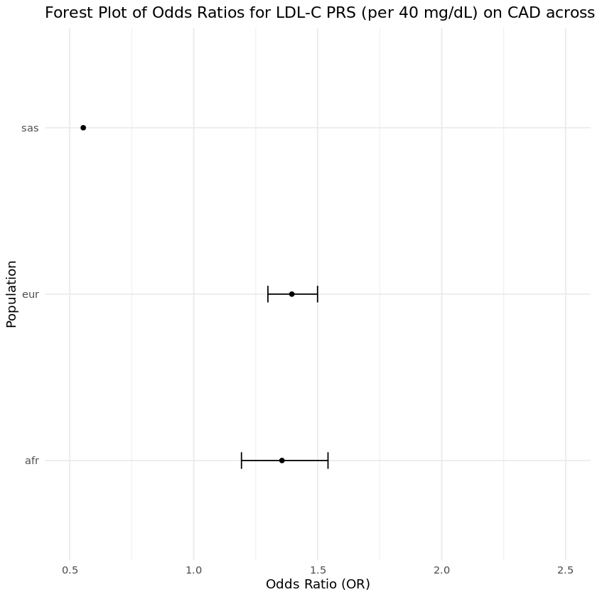

```r
names(glm_models)=populations

results <- data.frame(Population = character(),
                      OR = numeric(),
                      Lower = numeric(),
                      Upper = numeric(),
                      stringsAsFactors = FALSE)

for (pop in names(glm_models)) {
    model_summary <- tidy(cox_models[[pop]], conf.int = TRUE, exponentiate = TRUE)

    if ("scaled_ldl_prs" %in% model_summary$term) {
        term_row <- model_summary %>% filter(term == "scaled_ldl_prs")

        results <- rbind(results, data.frame(Population = pop,
                                             OR = term_row$estimate,
                                             Lower = term_row$conf.low,
                                             Upper = term_row$conf.high))
    } else {
        results <- rbind(results, data.frame(Population = pop, OR = NA, Lower = NA, Upper = NA))
    }
}
# # Create the forest plot using ggplot2
#
ggplot(results, aes(x = Population, y = OR, ymin = Lower, ymax = Upper)) +
    geom_point() +
    geom_errorbar(aes(ymin = Lower, ymax = Upper), width = 0.1) +
    coord_flip()+ylim(c(0.5,2.5))+
    xlab("Population") +
    ylab("Odds Ratio (OR)") +
    ggtitle("Forest Plot of Odds Ratios for LDL-C PRS (per 40 mg/dL) on CAD across Populations") +theme_minimal()
```

### Here's what happens if we do the population spsecific scaling

```r
#List of unique populations
populations <- c("afr","sas","eur")

#Initialize an empty list for storing models and results
cox_models <- list()
glm_models=list()
for(pop in populations)
{
    print(pop)

#Subset data for the specific population
  pop_data_ldl<-ldldat[ldldat$Population%in%pop,]
  pop_data_cad<-caddat[caddat$Population%in%pop,]
 #print(nrow(pop_data_ldl))
    #print(nrow(pop_data_cad))

    # There are three choices for PRS, we can use the overall residual,
    #the scaled (overall residuals), or the population scaled residual

    #Choose residual score or PRS, here we use the populations scaled prs

    ## population scaled
    pop_data_ldl$PRS=pop_data_ldl$scaled_prs
    ## unscaled residual score

    #pop_data_ldl$PRS=pop_data_ldl$residscore

    ## scaled residual score (not population)
    #pop_data_ldl$PRS=pop_data_ldl$scaled_residscore

 print(paste0("population summary prs for population",pop))
    print(summary(pop_data_ldl$PRS))

    pop_data_ldl$sex=as.factor(ifelse(pop_data_ldl$sex_report=="Male",1,0))

    #print(paste0("Sex_summary for pop",pop))

    #print(summary(as.factor(pop_data_ldl$sex)))


      # Step 1: Linear Regression for LDL-C Levels
ldl_model <- lm(max_measurement ~ PRS + as.numeric(age) + as.factor(sex)+
                PC1+PC2+PC3+PC4+PC5+PC6+PC7+PC8+PC9+PC10,
                   data = pop_data_ldl)
  #summary(ldl_model)
  print(paste("LDL_coef_CI:",pop,":"))
round(confint(ldl_model,parm = "PRS"),1)

   prs_scale_factor <- 40 / coef(ldl_model)["PRS"]

  print(paste("population scale factor:",round(prs_scale_factor,1)))

          pop_data_ldl$scaled_ldl_prs <- pop_data_ldl$PRS / prs_scale_factor
ldl_model_2 <- lm(max_measurement ~ scaled_ldl_prs + as.numeric(age) + as.factor(sex)+
                PC1+PC2+PC3+PC4+PC5+PC6+PC7+PC8+PC9+PC10,
                   data = pop_data_ldl)

print(paste("LDL_scaled_coef_CI:",pop,":",ldl_model_2$coefficients['scaled_ldl_prs']))

  pop_data_cad$scaled_ldl_prs <- pop_data_cad$PRS / prs_scale_factor
  pop_data_cad$sex=as.factor(ifelse(pop_data_cad$sex_report=="Male",1,0))

  # Step 2: Cox or GLM  for CAD
  cox_model <- coxph(Surv(total_censor_age, total_pheno) ~ scaled_ldl_prs+ as.numeric(age)+as.factor(sex)+
                     PC1+PC2+PC3+PC4+PC5+PC6+PC7+PC8+PC9+PC10,
                     data = pop_data_cad)
    ci=round(summary(cox_model)$conf.int['scaled_ldl_prs',],1)
    print(paste("lci:",ci[3],",HR:",ci[1],",uci:",ci[4]))
 glm_model <- glm(total_pheno ~ scaled_ldl_prs+ as.numeric(age)+as.factor(sex)+
                     PC1+PC2+PC3+PC4+PC5+PC6+PC7+PC8+PC9+PC10,
                     data = pop_data_cad,family="binomial")

    log_or=summary(glm_model)$coefficients["scaled_ldl_prs","Estimate"]
    log_or_se=summary(glm_model)$coefficients["scaled_ldl_prs","Std. Error"]
    or=round(exp(log_or),2)
    lci=round(exp(log_or-1.96*log_or_se),2)
    uci=round(exp(log_or+1.96*log_or_se),2)
    print(paste(pop,"LCI:",lci,",OR:",or,";UCI",uci))

  cox_models[[pop]] <- cox_model
  glm_models[[pop]] = glm_model
          }
```

```
[1] "afr"
[1] "population summary prs for populationafr"
    Min.  1st Qu.   Median     Mean  3rd Qu.     Max.
-3.72740 -0.65208  0.01496  0.01905  0.68754  4.41462
[1] "LDL_coef_CI: afr :"
[1] "population scale factor: 3.9"
[1] "LDL_scaled_coef_CI: afr : 40"
[1] "lci: 1.7 ,HR: 2.4 ,uci: 3.6"
[1] "afr LCI: 1.72 ,OR: 2.55 ;UCI 3.79"
[1] "sas"
[1] "population summary prs for populationsas"
    Min.  1st Qu.   Median     Mean  3rd Qu.     Max.
-4.21738 -0.64224  0.07332  0.03199  0.75138  3.07340
[1] "LDL_coef_CI: sas :"
[1] "population scale factor: 9.3"
[1] "LDL_scaled_coef_CI: sas : 40"
[1] "lci: 0 ,HR: 0 ,uci: 395.6"
[1] "sas LCI: 0 ,OR: 0.09 ;UCI 2159.56"
[1] "eur"
[1] "population summary prs for populationeur"
     Min.   1st Qu.    Median      Mean   3rd Qu.      Max.
-4.438284 -0.662208  0.013144  0.004914  0.688255  3.984832
[1] "LDL_coef_CI: eur :"
[1] "population scale factor: 3.6"
[1] "LDL_scaled_coef_CI: eur : 40"
[1] "lci: 2.1 ,HR: 2.6 ,uci: 3.2"
[1] "eur LCI: 2.2 ,OR: 2.74 ;UCI 3.41"
```

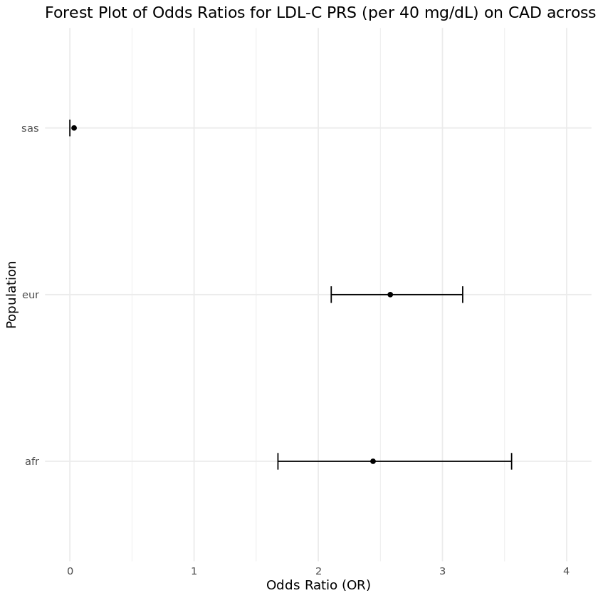

```r
names(glm_models)=populations

results <- data.frame(Population = character(),
                      OR = numeric(),
                      Lower = numeric(),
                      Upper = numeric(),
                      stringsAsFactors = FALSE)

for (pop in names(glm_models)) {
    model_summary <- tidy(cox_models[[pop]], conf.int = TRUE, exponentiate = TRUE)

    if ("scaled_ldl_prs" %in% model_summary$term) {
        term_row <- model_summary %>% filter(term == "scaled_ldl_prs")

        results <- rbind(results, data.frame(Population = pop,
                                             OR = term_row$estimate,
                                             Lower = term_row$conf.low,
                                             Upper = term_row$conf.high))
    } else {
        results <- rbind(results, data.frame(Population = pop, OR = NA, Lower = NA, Upper = NA))
    }
}
# # Create the forest plot using ggplot2
#
ggplot(results, aes(x = Population, y = OR, ymin = Lower, ymax = Upper)) +
    geom_point() +
    geom_errorbar(aes(ymin = Lower, ymax = Upper), width = 0.1) +
    coord_flip()+ylim(c(0,4))+
    xlab("Population") +
    ylab("Odds Ratio (OR)") +
    ggtitle("Forest Plot of Odds Ratios for LDL-C PRS (per 40 mg/dL) on CAD across Populations") +theme_minimal()
```

### And finally, for overall (not population specific) resdiaul scaling:

```r
#List of unique populations
populations <- c("afr","sas","eur")

#Initialize an empty list for storing models and results
cox_models <- list()
glm_models=list()
for(pop in populations)
{
    print(pop)

#Subset data for the specific population
  pop_data_ldl<-ldldat[ldldat$Population%in%pop,]
  pop_data_cad<-caddat[caddat$Population%in%pop,]
 #print(nrow(pop_data_ldl))
    #print(nrow(pop_data_cad))

    # There are three choices for PRS, we can use the overall (unscaled) residual,
    #the scaled (overall residuals), or the population scaled residual

    #Choose residual score or PRS, here we use the populations scaled prs

    ## population scaled
    #pop_data_ldl$PRS=pop_data_ldl$scaled_prs
    ## unscaled residual score

    #pop_data_ldl$PRS=pop_data_ldl$residscore

    ## scaled residual score (not population)
    pop_data_ldl$PRS=pop_data_ldl$scaled_residscore

     print(paste0("population summary prs for population",pop))
    print(summary(pop_data_ldl$PRS))

    pop_data_ldl$sex=as.factor(ifelse(pop_data_ldl$sex_report=="Male",1,0))

    #print(paste0("Sex_summary for pop",pop))

    #print(summary(as.factor(pop_data_ldl$sex)))


      # Step 1: Linear Regression for LDL-C Levels
ldl_model <- lm(max_measurement ~ PRS + as.numeric(age) + as.factor(sex)+
                PC1+PC2+PC3+PC4+PC5+PC6+PC7+PC8+PC9+PC10,
                   data = pop_data_ldl)
  #summary(ldl_model)
  print(paste("LDL_coef_CI:",pop,":"))
round(confint(ldl_model,parm = "PRS"),1)

   prs_scale_factor <- 40 / coef(ldl_model)["PRS"]

  print(paste("population scale factor:",round(prs_scale_factor,1)))

          pop_data_ldl$scaled_ldl_prs <- pop_data_ldl$PRS / prs_scale_factor
ldl_model_2 <- lm(max_measurement ~ scaled_ldl_prs + as.numeric(age) + as.factor(sex)+
                PC1+PC2+PC3+PC4+PC5+PC6+PC7+PC8+PC9+PC10,
                   data = pop_data_ldl)

print(paste("LDL_scaled_coef_CI:",pop,":",ldl_model_2$coefficients['scaled_ldl_prs']))

  pop_data_cad$scaled_ldl_prs <- pop_data_cad$PRS / prs_scale_factor
  pop_data_cad$sex=as.factor(ifelse(pop_data_cad$sex_report=="Male",1,0))

  # Step 2: Cox or GLM  for CAD
  cox_model <- coxph(Surv(total_censor_age, total_pheno) ~ scaled_ldl_prs+ as.numeric(age)+as.factor(sex)+
                     PC1+PC2+PC3+PC4+PC5+PC6+PC7+PC8+PC9+PC10,
                     data = pop_data_cad)
    ci=round(summary(cox_model)$conf.int['scaled_ldl_prs',],1)
    print(paste("lci:",ci[3],",HR:",ci[1],",uci:",ci[4]))
 glm_model <- glm(total_pheno ~ scaled_ldl_prs+ as.numeric(age)+as.factor(sex)+
                     PC1+PC2+PC3+PC4+PC5+PC6+PC7+PC8+PC9+PC10,
                     data = pop_data_cad,family="binomial")

    log_or=summary(glm_model)$coefficients["scaled_ldl_prs","Estimate"]
    log_or_se=summary(glm_model)$coefficients["scaled_ldl_prs","Std. Error"]
    or=round(exp(log_or),2)
    lci=round(exp(log_or-1.96*log_or_se),2)
    uci=round(exp(log_or+1.96*log_or_se),2)
    print(paste(pop,"LCI:",lci,",OR:",or,";UCI",uci))

  cox_models[[pop]] <- cox_model
  glm_models[[pop]] = glm_model
          }
```

```
[1] "afr"
[1] "population summary prs for populationafr"
    Min.  1st Qu.   Median     Mean  3rd Qu.     Max.
-3.64149 -0.61602  0.04021  0.04423  0.70188  4.36855
[1] "LDL_coef_CI: afr :"
[1] "population scale factor: 3.9"
[1] "LDL_scaled_coef_CI: afr : 40"
[1] "lci: 1.7 ,HR: 2.4 ,uci: 3.5"
[1] "afr LCI: 1.71 ,OR: 2.52 ;UCI 3.71"
[1] "sas"
[1] "population summary prs for populationsas"
    Min.  1st Qu.   Median     Mean  3rd Qu.     Max.
-2.41742 -0.61997 -0.26022 -0.28100  0.08068  1.24811
[1] "LDL_coef_CI: sas :"
[1] "population scale factor: 4.7"
[1] "LDL_scaled_coef_CI: sas : 40"
[1] "lci: 0 ,HR: 0.2 ,uci: 20.2"
[1] "sas LCI: 0 ,OR: 0.3 ;UCI 47.47"
[1] "eur"
[1] "population summary prs for populationeur"
     Min.   1st Qu.    Median      Mean   3rd Qu.      Max.
-4.506518 -0.675541  0.009630  0.001281  0.694557  4.039064
[1] "LDL_coef_CI: eur :"
[1] "population scale factor: 3.7"
[1] "LDL_scaled_coef_CI: eur : 40"
[1] "lci: 2.1 ,HR: 2.6 ,uci: 3.2"
[1] "eur LCI: 2.23 ,OR: 2.78 ;UCI 3.48"
```

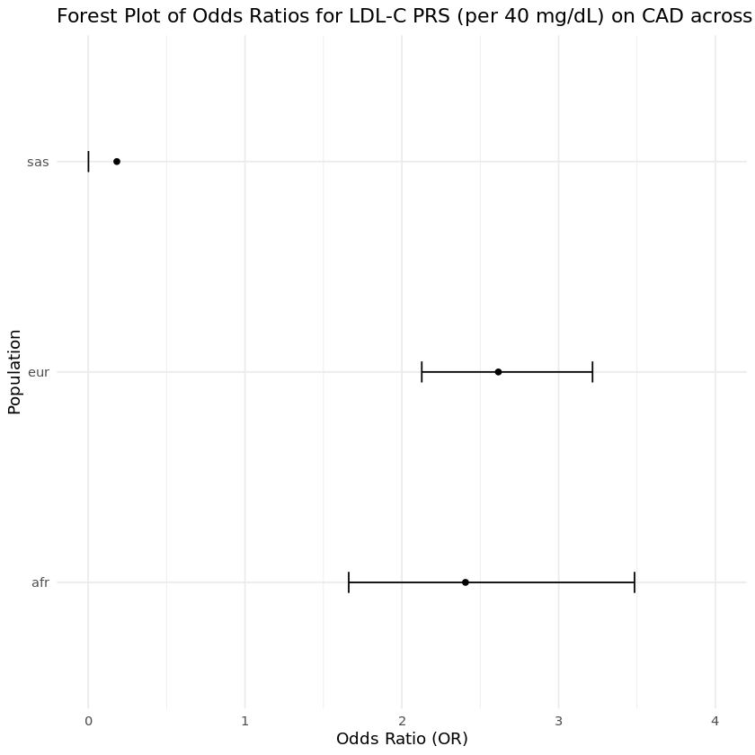

```r
names(glm_models)=populations

results <- data.frame(Population = character(),
                      OR = numeric(),
                      Lower = numeric(),
                      Upper = numeric(),
                      stringsAsFactors = FALSE)

for (pop in names(glm_models)) {
    model_summary <- tidy(cox_models[[pop]], conf.int = TRUE, exponentiate = TRUE)

    if ("scaled_ldl_prs" %in% model_summary$term) {
        term_row <- model_summary %>% filter(term == "scaled_ldl_prs")

        results <- rbind(results, data.frame(Population = pop,
                                             OR = term_row$estimate,
                                             Lower = term_row$conf.low,
                                             Upper = term_row$conf.high))
    } else {
        results <- rbind(results, data.frame(Population = pop, OR = NA, Lower = NA, Upper = NA))
    }
}
# # Create the forest plot using ggplot2
#
ggplot(results, aes(x = Population, y = OR, ymin = Lower, ymax = Upper)) +
    geom_point() +
    geom_errorbar(aes(ymin = Lower, ymax = Upper), width = 0.1) +
    coord_flip()+ylim(c(0,4))+
    xlab("Population") +
    ylab("Odds Ratio (OR)") +
    ggtitle("Forest Plot of Odds Ratios for LDL-C PRS (per 40 mg/dL) on CAD across Populations") +theme_minimal()
```